# Supervised Machine Learning

```
                                                                                    Aryan Jain
```

#### PROJECT SUMMARY

**Data Description:** The file Bank.xls contains data on 5000 customers. The data include customer demographic information (age, income, etc.), the customer's relationship with the bank (mortgage, securities account, etc.), and the customer response to the last personal loan campaign (Personal Loan). Among these 5000 customers, only 480 (= 9.6%) accepted the personal loan that was offered to them in the earlier campaign.

**Domain:** Banking

**Context:** This case is about a bank (Thera Bank)whose management wants to explore ways of converting its liability customers to personal loan customers (while retaining them as depositors). A campaign that the bank ran last year for liability customers showed a healthy conversion rate of over 9% success. This has encouraged the retail marketing department to devise campaigns with better target marketing to increase the success ratio with minimal budget.

**Objective:** The classification goal is to predict the likelihood of a liability customer buying personal loans.

**Attribute Information**

- **`ID`**: Customer ID
- **`Age`**: Customer's age in completed years
- **`Experience`** : #years of professional experience
- **`Income`**: Annual income of the customer (thousand dollars)
- **`ZIP Code`**: Home Address ZIP code.
- **`Family`**: Family size of the customer
- **`CCAvg`**: Avg. spending on credit cards per month (thousand dollars)
- **`Education`**: Education Level. 1: Undergrad; 2: Graduate; 3: Advanced/Professional
- **`Mortgage`**: Value of house mortgage if any. (thousand dollars)
- **`Personal Loan`**: Did this customer accept the personal loan offered in the last campaign?
- **`Securities Account`**: Does the customer have a securities account with the bank?
- **`CD Account`**: Does the customer have a certificate of deposit (CD) account with the bank?
- **`Online`**: Does the customer use internet banking facilities?
- **`Credit card`**: Does the customer use a credit card issued by bank

**Learning Outcomes**

- Exploratory Data Analysis
- Preparing the data to train a model
- Training and making predictions using a classification model
- Model evaluation

## Importing Libraries

#### Libraries for Data Management and Vizualization

```python
import pandas as pd
import numpy as np
import matplotlib.pyplot as plt
%matplotlib inline
import seaborn as sns
```

#### Libraries for the various classifiers

```python
from sklearn.naive_bayes import GaussianNB
from sklearn.linear_model import LogisticRegression
from sklearn.neighbors import KNeighborsClassifier
from sklearn.model_selection import train_test_split
```

#### Library to score the models

```python
from sklearn import metrics
```

### Loading the data

```python
bank_df = pd.read_csv('Bank_Personal_Loan_Modelling.csv')
```

## Getting to know the dataset

```python
# Printing the first 5 rows of the dataset
bank_df.head()
```

|  | ID | Age | Experience | Income | ZIP Code | Family | CCAvg | Education | Mortgage | Personal Loan | Securities Account | CD Account | Online | CreditCard |
| --- | --- | --- | --- | --- | --- | --- | --- | --- | --- | --- | --- | --- | --- | --- |
| 0 | 1 | 25 | 1 | 49 | 91107 | 4 | 1.6 | 1 | 0 | 0 | 1 | 0 | 0 | 0 |
| 1 | 2 | 45 | 19 | 34 | 90089 | 3 | 1.5 | 1 | 0 | 0 | 1 | 0 | 0 | 0 |
| 2 | 3 | 39 | 15 | 11 | 94720 | 1 | 1.0 | 1 | 0 | 0 | 0 | 0 | 0 | 0 |
| 3 | 4 | 35 | 9 | 100 | 94112 | 1 | 2.7 | 2 | 0 | 0 | 0 | 0 | 0 | 0 |
| 4 | 5 | 35 | 8 | 45 | 91330 | 4 | 1.0 | 2 | 0 | 0 | 0 | 0 | 0 | 1 |

```python
# Get information about the dataset
bank_df.info()
```

```
<class 'pandas.core.frame.DataFrame'>
RangeIndex: 5000 entries, 0 to 4999
Data columns (total 14 columns):
 #   Column              Non-Null Count  Dtype
---  ------              --------------  -----
 0   ID                  5000 non-null   int64
 1   Age                 5000 non-null   int64
 2   Experience          5000 non-null   int64
 3   Income              5000 non-null   int64
 4   ZIP Code            5000 non-null   int64
 5   Family              5000 non-null   int64
 6   CCAvg               5000 non-null   float64
 7   Education           5000 non-null   int64
 8   Mortgage            5000 non-null   int64
 9   Personal Loan       5000 non-null   int64
 10  Securities Account  5000 non-null   int64
 11  CD Account          5000 non-null   int64
 12  Online              5000 non-null   int64
 13  CreditCard          5000 non-null   int64
dtypes: float64(1), int64(13)
memory usage: 547.0 KB
```

```python
bank_df.shape
```

```
(5000, 14)
```

**OBSERVATIONS**

- `This dataset has 5000 rows and 14 columns, including 13 independent variables and 1 target variable`
- `No missing values are present in the dataframe`

### Exploratory Data Analysis

#### Getting summary of numerical data

```python
bank_df.describe()
```

|  | ID | Age | Experience | Income | ZIP Code | Family | CCAvg | Education | Mortgage | Personal Loan | Securities Account | CD Account | Online | CreditCard |
| --- | --- | --- | --- | --- | --- | --- | --- | --- | --- | --- | --- | --- | --- | --- |
| count | 5000.000000 | 5000.000000 | 5000.000000 | 5000.000000 | 5000.000000 | 5000.000000 | 5000.000000 | 5000.000000 | 5000.000000 | 5000.000000 | 5000.000000 | 5000.00000 | 5000.000000 | 5000.000000 |
| mean | 2500.500000 | 45.338400 | 20.104600 | 73.774200 | 93152.503000 | 2.396400 | 1.937938 | 1.881000 | 56.498800 | 0.096000 | 0.104400 | 0.06040 | 0.596800 | 0.294000 |
| std | 1443.520003 | 11.463166 | 11.467954 | 46.033729 | 2121.852197 | 1.147663 | 1.747659 | 0.839869 | 101.713802 | 0.294621 | 0.305809 | 0.23825 | 0.490589 | 0.455637 |
| min | 1.000000 | 23.000000 | -3.000000 | 8.000000 | 9307.000000 | 1.000000 | 0.000000 | 1.000000 | 0.000000 | 0.000000 | 0.000000 | 0.00000 | 0.000000 | 0.000000 |
| 25% | 1250.750000 | 35.000000 | 10.000000 | 39.000000 | 91911.000000 | 1.000000 | 0.700000 | 1.000000 | 0.000000 | 0.000000 | 0.000000 | 0.00000 | 0.000000 | 0.000000 |
| 50% | 2500.500000 | 45.000000 | 20.000000 | 64.000000 | 93437.000000 | 2.000000 | 1.500000 | 2.000000 | 0.000000 | 0.000000 | 0.000000 | 0.00000 | 1.000000 | 0.000000 |
| 75% | 3750.250000 | 55.000000 | 30.000000 | 98.000000 | 94608.000000 | 3.000000 | 2.500000 | 3.000000 | 101.000000 | 0.000000 | 0.000000 | 0.00000 | 1.000000 | 1.000000 |
| max | 5000.000000 | 67.000000 | 43.000000 | 224.000000 | 96651.000000 | 4.000000 | 10.000000 | 3.000000 | 635.000000 | 1.000000 | 1.000000 | 1.00000 | 1.000000 | 1.000000 |

**Observations**

```
Carefully examined each variable for type (Categorical / Continuous, Qualitative / Quantitative). Few key take aways     are following:
```

- `ID is a categorical variable, with min value 1 and maximum 5000. Total 5000 rows. Let's check if it's a unique row identifier and has no other meaning`
- `EXPERIENCE shows min value as negative 3. This indicates data error`
- `FAMILY size are 1,2,3 or 4`
- `ZIP codes - 5 digits, data appears for USA`
- `EDUCATION - 3 levels: 1 (Undergrad), 2 (Graduate), 3 (Advanced/Professional)`
- `CCAVG and MORTGAGE: there are people with zero CCAVG and/or Mortgage`

```python
bank_df['ID'].nunique()
```

```
5000
```

**Observations**

- `Clearly, ID is a identifier with no predictive purpose`

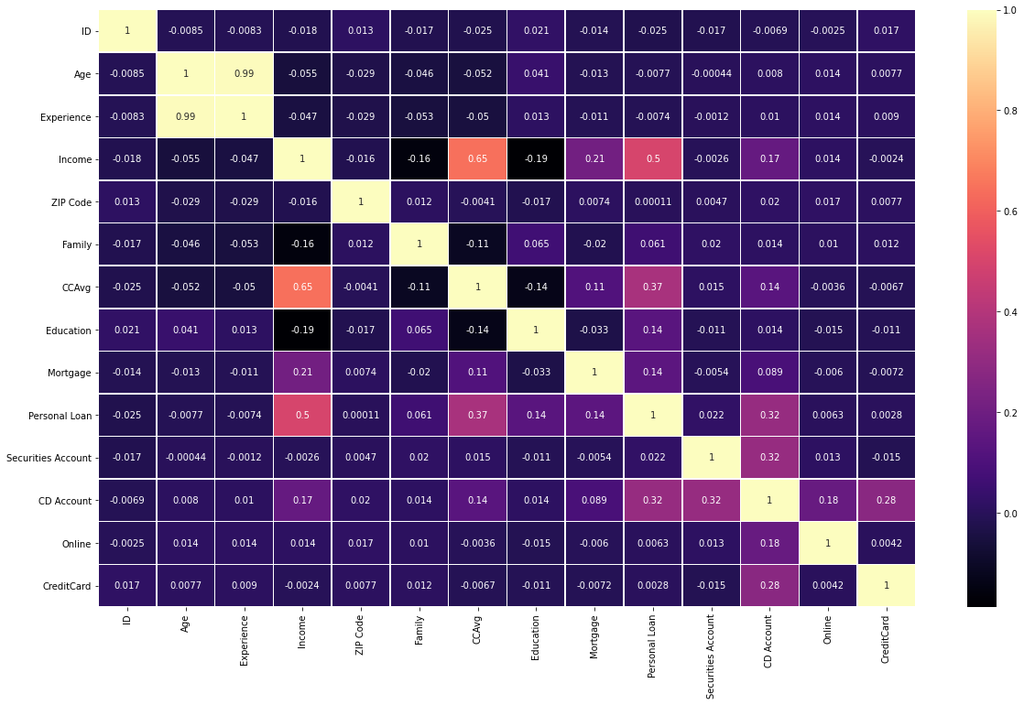

```python
# Correlation of variables
corr_matrix = bank_df.corr()
df_corr = pd.DataFrame(corr_matrix)
plt.figure(figsize = (20,12))
sns.heatmap(df_corr, annot=True, fmt='.2g', cmap='magma', linewidths=0.5);
```

**Observations**

- `I am setting a threshold for correlation of independent variables with target variable. When Corr < 0.01, we assume this has no use (negligible) in predicting the target variable. Will drop such independent variables.`
- `Based on above criteria, I will drop the Age, Experience, Online, zipcode & credit card variables`
- `Based on earlier observation, ID is a just a unique row identifier, hence dropping it as well.`

```python
bank_df.drop(['Age','Experience','Online', 'CreditCard', 'ZIP Code', 'ID'], axis=1, inplace=True)
```

```python
bank_df.head()
```

|  | Income | Family | CCAvg | Education | Mortgage | Personal Loan | Securities Account | CD Account |
| --- | --- | --- | --- | --- | --- | --- | --- | --- |
| 0 | 49 | 4 | 1.6 | 1 | 0 | 0 | 1 | 0 |
| 1 | 34 | 3 | 1.5 | 1 | 0 | 0 | 1 | 0 |
| 2 | 11 | 1 | 1.0 | 1 | 0 | 0 | 0 | 0 |
| 3 | 100 | 1 | 2.7 | 2 | 0 | 0 | 0 | 0 |
| 4 | 45 | 4 | 1.0 | 2 | 0 | 0 | 0 | 0 |

**Observation**

- `The data frame now has reduced number of independent variables (reduced from from 13 to 7)`

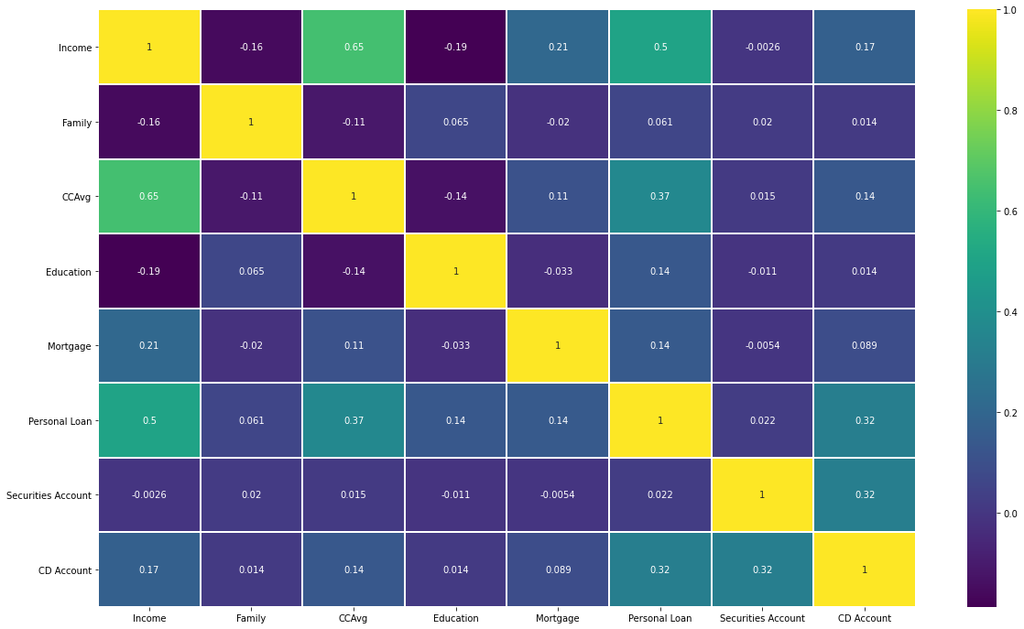

```python
# Let's look at the new correlation matrix
corr_matrix = bank_df.corr()
df_corr = pd.DataFrame(corr_matrix)
plt.figure(figsize = (20,12))
sns.heatmap(df_corr, annot=True, fmt='.2g', cmap='viridis', linewidths=1);
```

**Observations**

- `The correlation between target & any independent variables are above threshold level 0.01`

## Distribution of target variable (Personal Loan)

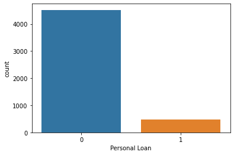

```python
sns.countplot(bank_df['Personal Loan']);
```

```python
print(bank_df['Personal Loan'].value_counts())
print(bank_df['Personal Loan'].value_counts(normalize=True)*100)
```

```
0    4520
1     480
Name: Personal Loan, dtype: int64
0    90.4
1     9.6
Name: Personal Loan, dtype: float64
```

**OBSERVATION:**

- `Total customer = 5000, Customer accepted loan = 480, thats only 9.6%`

### Looking at how every independent variable affects the target variable

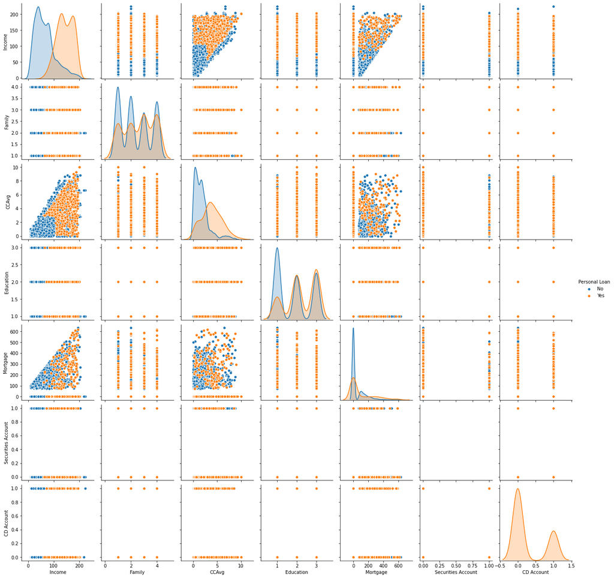

```python
pairplt = bank_df.copy()
pairplt['Personal Loan'] = pairplt['Personal Loan'].replace({0:'No', 1:'Yes'})
sns.pairplot(pairplt, hue='Personal Loan');
```

**OBSERVATION:**

**Relation between Income and Target**

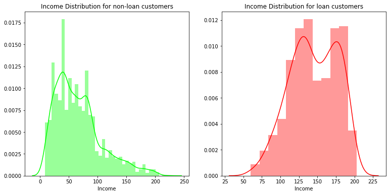

```python
fig = plt.figure(figsize = (12.8, 6))

ax = fig.add_subplot(121)
sns.distplot(bank_df[(bank_df['Personal Loan'] == 0)]['Income'], color = 'lime',
             ax = ax).set_title("Income Distribution for non-loan customers")

ax= fig.add_subplot(122)
sns.distplot(bank_df[(bank_df['Personal Loan'] == 1)]['Income'], color = 'r',
             ax = ax).set_title('Income Distribution for loan customers')

plt.show()
```

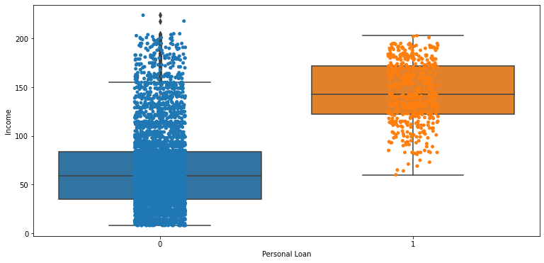

```python
fig = plt.figure(figsize = (12.8, 6))
ax = sns.boxplot(x='Personal Loan',y='Income', data=bank_df)
ax = sns.stripplot(x='Personal Loan',y='Income', data=bank_df)
```

**Relation between Average spending on credit card and Target**

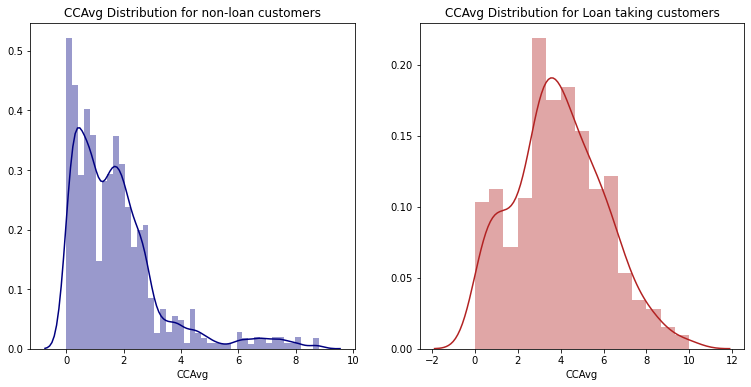

```python
fig = plt.figure(figsize = (12.8, 6))

ax = fig.add_subplot(121)
sns.distplot(bank_df[(bank_df['Personal Loan'] == 0)]['CCAvg'], color = 'navy',
             ax = ax).set_title("CCAvg Distribution for non-loan customers")

ax= fig.add_subplot(122)
sns.distplot(bank_df[(bank_df['Personal Loan'] == 1)]['CCAvg'], color = 'firebrick',
             ax = ax).set_title('CCAvg Distribution for Loan taking customers')

plt.show()
```

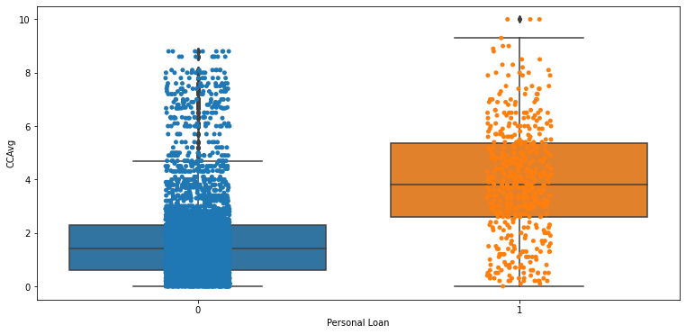

```python
fig = plt.figure(figsize = (12.8, 6))
ax = sns.boxplot(x='Personal Loan',y='CCAvg', data=bank_df)
ax = sns.stripplot(x='Personal Loan',y='CCAvg', data=bank_df)
```

**Relation between Mortgage and Target**

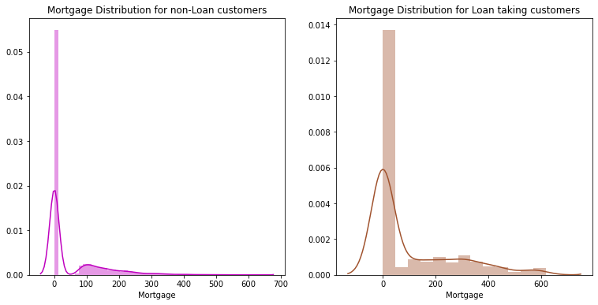

```python
fig = plt.figure(figsize = (12.8, 6))

ax = fig.add_subplot(121)
sns.distplot(bank_df[(bank_df['Personal Loan'] == 0)]['Mortgage'], color = 'm',
             ax = ax).set_title('Mortgage Distribution for non-Loan customers')

ax= fig.add_subplot(122)
sns.distplot(bank_df[(bank_df['Personal Loan'] == 1)]['Mortgage'], color = 'sienna',
             ax = ax).set_title('Mortgage Distribution for Loan taking customers')

plt.show()
```

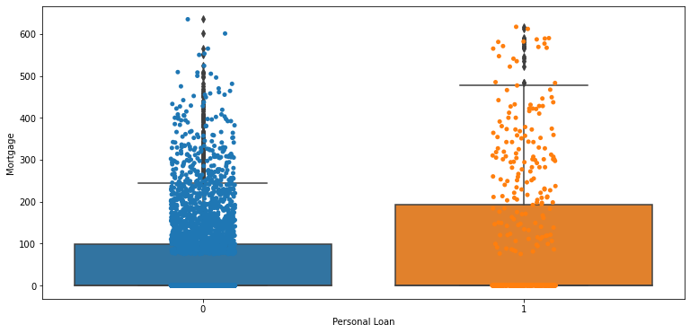

```python
fig = plt.figure(figsize = (12.8, 6))
ax = sns.boxplot(x='Personal Loan',y='Mortgage', data=bank_df)
ax = sns.stripplot(x='Personal Loan',y='Mortgage', data=bank_df)
```

**Relation between Family size and Target**

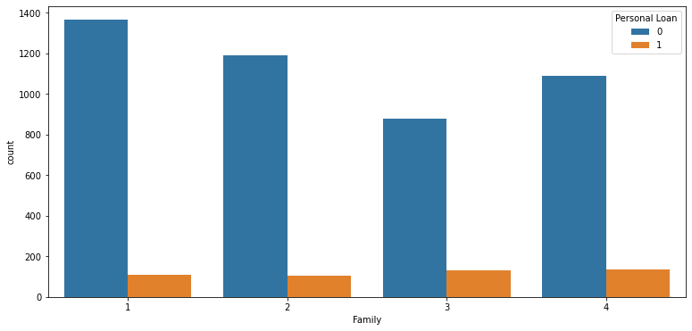

```python
fig = plt.figure(figsize = (12.8, 6))
sns.countplot(x='Family', hue='Personal Loan',data=bank_df);
```

**Relation between Education and Target**

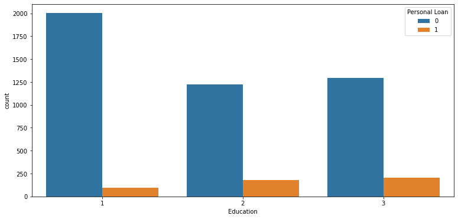

```python
fig = plt.figure(figsize = (12.8, 6))
sns.countplot(x='Education', hue='Personal Loan',data=bank_df),
```

**Relation between CD Account and Target**

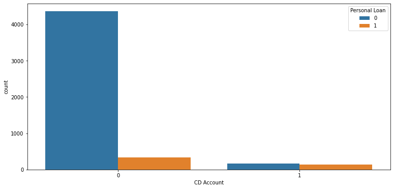

```python
fig = plt.figure(figsize = (12.8, 6))
sns.countplot(x='CD Account', hue='Personal Loan',data=bank_df);
```

**Observations**

- `People who accepted Loan are more in Higher income level`
- `People who accepted Loan have higher Credit card spend`
- `Higher educated people have higher rate of accepting Loan`
- `People with CD Accounts seem to have higher rate of accepting Load than people without CD account`
- `Family size 3-4 have slightly higher rate of accepting Loan than family size 1-2`

## Modelling

```python
X = bank_df.drop('Personal Loan', axis=1)
y = bank_df['Personal Loan']
```

```python
# Splitting data into training and testing data with 70:30 ratio
X_train , X_test , y_train , y_test = train_test_split(X, y, train_size=0.7, random_state=1)
```

### Logistic Regression

```python
# Initializing the model
logReg = LogisticRegression(solver='liblinear', random_state=1)
```

```python
# Training the model on training set of data
logReg.fit(X_train , y_train)
```

```
LogisticRegression(random_state=1, solver='liblinear')
```

```python
# Predicting the testing data
y_pred_logreg = logReg.predict(X_test)
```

**Scoring the model**

```python
# Scoring the model
print('Logistic Regression', end='\n\n')
print(f'\tTraining Accuracy: {logReg.score(X_train,y_train)}')
print(f'\tTesting Accurancy: {logReg.score(X_test,y_test)}')
```

```
Logistic Regression

	Training Accuracy: 0.9491428571428572
	Testing Accurancy: 0.946
```

`PERFORMANCE REPORT`

```python
report = metrics.classification_report(y_test , y_pred_logreg)
print("Performance Report:", end='\n\n')
print(report)
```

```
Performance Report:

              precision    recall  f1-score   support

           0       0.95      0.99      0.97      1351
           1       0.89      0.52      0.66       149

    accuracy                           0.95      1500
   macro avg       0.92      0.76      0.81      1500
weighted avg       0.94      0.95      0.94      1500
```

`CONFUSION MATRIX`

```
Confusion Matrix:
```

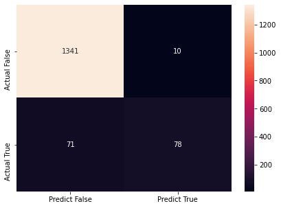

```python
cm=metrics.confusion_matrix(y_test, y_pred_logreg, labels=[0, 1])
print("Confusion Matrix: ")

df_cm = pd.DataFrame(cm, index = [i for i in ["Actual False","Actual True"]],
                  columns = [i for i in ["Predict False","Predict True"]])
plt.figure(figsize = (7,5))
sns.heatmap(df_cm, annot=True, fmt='d')
plt.show()
```

`ACCURACY`

```python
acc_logreg = metrics.accuracy_score(y_test , y_pred_logreg)
print(f"Accuracy: {acc_logreg}")
```

```
Accuracy: 0.946
```

**Observations**

- `Model accuracy on training dataset ~ 94.9%`
- `Model Accuracy on testing dataset ~ 94.6%`
- `The Accuracy 94.6% is pretty good for such marketing campaign. Hence, no hypertuning is required.`
- `Accuracy with Training data and Testing data are almost same, hence appears to be a very good fit.`

### Naive Bayes Classifier

```python
# Initializing the model
nb = GaussianNB()
```

```python
# Training the model on training set of data
nb.fit(X_train , y_train)
```

```
GaussianNB()
```

```python
# Predicting the testing data
y_pred_nb = nb.predict(X_test)
```

**Scoring the model**

```python
print('Naive Bayes:', end='\n\n')
print(f'\tTraining Accuracy: {nb.score(X_train,y_train)}')
print(f'\tTesting Accuracy: {nb.score(X_test,y_test)}')
```

```
Naive Bayes:

	Training Accuracy: 0.8897142857142857
	Testing Accuracy: 0.8753333333333333
```

`PERFORMANCE REPORT`

```python
report = metrics.classification_report(y_test , y_pred_nb)
print("Performance Report:", end='\n\n')
print(report)
```

```
Performance Report:

              precision    recall  f1-score   support

           0       0.95      0.91      0.93      1351
           1       0.41      0.57      0.48       149

    accuracy                           0.88      1500
   macro avg       0.68      0.74      0.70      1500
weighted avg       0.90      0.88      0.88      1500
```

`CONFUSION MATRIX`

```
Confusion Matrix:
```

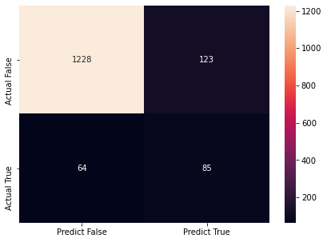

```python
cm=metrics.confusion_matrix(y_test, y_pred_nb, labels=[0, 1])
print("Confusion Matrix: ")

df_cm = pd.DataFrame(cm, index = [i for i in ["Actual False","Actual True"]],
                  columns = [i for i in ["Predict False","Predict True"]])
plt.figure(figsize = (7,5))
sns.heatmap(df_cm, annot=True, fmt='d')
plt.show()
```

`ACCURACY`

```python
acc_nb = metrics.accuracy_score(y_test , y_pred_nb)
print(f"Accuracy: {acc_nb}")
```

```
Accuracy: 0.8753333333333333
```

**Observation**

- `Accuracy is ~ 87.5%, which is lower than Logistic Regression model`

**Observations**

- `Model accuracy on training dataset ~ 89%`
- `Model Accuracy on testing dataset ~ 87.5%`
- `The Accuracy 87.5% is good for such marketing campaign, but logistic regression performed better.`
- `Based on the accuracy on Training data and Testing data, the difference is within acceptable range`

### k-Nearest Neighbors

```python
# Initializing the model
knn = KNeighborsClassifier()
```

```python
# Training the model on training set of data
knn.fit(X_train , y_train)
```

```
KNeighborsClassifier()
```

```python
# Predicting the testing data
y_pred_knn = knn.predict(X_test)
```

**Scoring the model**

```python
print('k-NN:', end='\n\n')
print(f'\tTraining Accuracy: {knn.score(X_train,y_train)}')
print(f'\tTesting Accuracy: {knn.score(X_test,y_test)}')
```

```
k-NN:

	Training Accuracy: 0.9557142857142857
	Testing Accuracy: 0.916
```

`PERFORMANCE REPORT`

```python
report = metrics.classification_report(y_test , y_pred_knn)
print("Performance Report:", end='\n\n')
print(report)
```

```
Performance Report:

              precision    recall  f1-score   support

           0       0.94      0.97      0.95      1351
           1       0.62      0.41      0.49       149

    accuracy                           0.92      1500
   macro avg       0.78      0.69      0.72      1500
weighted avg       0.91      0.92      0.91      1500
```

`CONFUSION MATRIX`

```
Confusion Matrix:
```

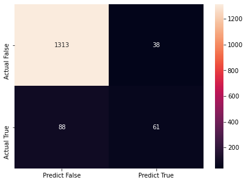

```python
cm=metrics.confusion_matrix(y_test, y_pred_knn, labels=[0, 1])
print("Confusion Matrix: ")

df_cm = pd.DataFrame(cm, index = [i for i in ["Actual False","Actual True"]],
                  columns = [i for i in ["Predict False","Predict True"]])
plt.figure(figsize = (7,5))
sns.heatmap(df_cm, annot=True, fmt='d')
plt.show()
```

`ACCURACY`

```python
acc_knn = metrics.accuracy_score(y_test , y_pred_knn)
print(f"Accuracy: {acc_knn}")
```

```
Accuracy: 0.916
```

**Observations**

- `Model accuracy on training dataset ~ 95.6%`
- `Model Accuracy on testing dataset ~ 91.6%`
- `The Accuracy 91.6% seems acceptable for such marketing campaign. Still, logistic regression performs better than kNN in this case.`
- `Based on the accuracy on Training data and Testing data, the model appears to be slightly overfitting the data.`

**Additional Notes:**

- `Considering the model is meant for marketing campaign, the accuracy close to 90% is pretty good. Therefore, we don't need to perform any hypertuning on our model`
- `The hypertuning is not yet covered in the modules so far, later in course, when I learn more about hypertuning, will start to implement it.`

## Performance summary

```python
summary_df = pd.DataFrame(columns=["Metric", "Logistic Regression", "Naive Bayes", "kNN"])
```

```python
summary_df.loc[0] = ["In-sample accuracy", "94.9%", "89%", "95.6%"]
summary_df.loc[1] = ["Out-of-sample accuracy", "94.6%", "87.5%", "91.6%"]
summary_df.loc[2] = ["Precision", "95%", "95%", "94%"]
summary_df.loc[3] = ["Recall", "99%", "91%", "97%"]
summary_df.loc[4] = ["F1-score", "97%", "93%", "95%"]
```

```python
summary_df.set_index("Metric", inplace=True)
```

```python
summary_df
```

| Metric | Logistic Regression | Naive Bayes | kNN |
| --- | --- | --- | --- |
| In-sample accuracy | 94.9% | 89% | 95.6% |
| Out-of-sample accuracy | 94.6% | 87.5% | 91.6% |
| Precision | 95% | 95% | 94% |
| Recall | 99% | 91% | 97% |
| F1-score | 97% | 93% | 95% |

## FINAL CONCLUSION

### Logistic Regression is the best suited model:

**Recap of Logistic Regression Scores:**

- `Precision - 95%`
- `Recall - 99%`
- `F1 score - 97%`
- `Accuracy ~ 95% (For both training and testing datasets)`

# --------------------------------------- END OF PROJECT --------------------------------------